# Risk Factor Analysis

## Outcome Variable

**Outcome Variable:** ever_stunted

## Predictor Variables

**Intervention Variable:** predfeed3

**Adjustment Set:**

unadjusted

## Stratifying Variables

The analysis was stratified on these variable(s):

- agecat
- studyid
- country

## Data Summary

| agecat | studyid | country | predfeed3 | ever_stunted | n_cell | n |
| --- | --- | --- | --- | --- | --- | --- |
| 0-24 months (no birth st.) | EE | PAKISTAN | 1 | 0 | 4 | 21 |
| 0-24 months (no birth st.) | EE | PAKISTAN | 1 | 1 | 17 | 21 |
| 0-24 months (no birth st.) | EE | PAKISTAN | 0 | 0 | 0 | 21 |
| 0-24 months (no birth st.) | EE | PAKISTAN | 0 | 1 | 0 | 21 |
| 0-24 months (no birth st.) | GMS-Nepal | NEPAL | 1 | 0 | 116 | 380 |
| 0-24 months (no birth st.) | GMS-Nepal | NEPAL | 1 | 1 | 201 | 380 |
| 0-24 months (no birth st.) | GMS-Nepal | NEPAL | 0 | 0 | 22 | 380 |
| 0-24 months (no birth st.) | GMS-Nepal | NEPAL | 0 | 1 | 41 | 380 |
| 0-24 months (no birth st.) | MAL-ED | BANGLADESH | 1 | 0 | 78 | 202 |
| 0-24 months (no birth st.) | MAL-ED | BANGLADESH | 1 | 1 | 86 | 202 |
| 0-24 months (no birth st.) | MAL-ED | BANGLADESH | 0 | 0 | 16 | 202 |
| 0-24 months (no birth st.) | MAL-ED | BANGLADESH | 0 | 1 | 22 | 202 |
| 0-24 months (no birth st.) | MAL-ED | BRAZIL | 1 | 0 | 69 | 175 |
| 0-24 months (no birth st.) | MAL-ED | BRAZIL | 1 | 1 | 17 | 175 |
| 0-24 months (no birth st.) | MAL-ED | BRAZIL | 0 | 0 | 75 | 175 |
| 0-24 months (no birth st.) | MAL-ED | BRAZIL | 0 | 1 | 14 | 175 |
| 0-24 months (no birth st.) | MAL-ED | INDIA | 1 | 0 | 48 | 184 |
| 0-24 months (no birth st.) | MAL-ED | INDIA | 1 | 1 | 79 | 184 |
| 0-24 months (no birth st.) | MAL-ED | INDIA | 0 | 0 | 35 | 184 |
| 0-24 months (no birth st.) | MAL-ED | INDIA | 0 | 1 | 22 | 184 |
| 0-24 months (no birth st.) | MAL-ED | NEPAL | 1 | 0 | 77 | 201 |
| 0-24 months (no birth st.) | MAL-ED | NEPAL | 1 | 1 | 28 | 201 |
| 0-24 months (no birth st.) | MAL-ED | NEPAL | 0 | 0 | 72 | 201 |
| 0-24 months (no birth st.) | MAL-ED | NEPAL | 0 | 1 | 24 | 201 |
| 0-24 months (no birth st.) | MAL-ED | PERU | 1 | 0 | 71 | 253 |
| 0-24 months (no birth st.) | MAL-ED | PERU | 1 | 1 | 95 | 253 |
| 0-24 months (no birth st.) | MAL-ED | PERU | 0 | 0 | 31 | 253 |
| 0-24 months (no birth st.) | MAL-ED | PERU | 0 | 1 | 56 | 253 |
| 0-24 months (no birth st.) | MAL-ED | SOUTH AFRICA | 1 | 0 | 31 | 237 |
| 0-24 months (no birth st.) | MAL-ED | SOUTH AFRICA | 1 | 1 | 35 | 237 |

[output cut: 78 more lines]

The following strata were considered:

- agecat: 0-24 months (no birth st.), studyid: EE, country: PAKISTAN
- agecat: 0-24 months (no birth st.), studyid: GMS-Nepal, country: NEPAL
- agecat: 0-24 months (no birth st.), studyid: MAL-ED, country: BANGLADESH
- agecat: 0-24 months (no birth st.), studyid: MAL-ED, country: BRAZIL
- agecat: 0-24 months (no birth st.), studyid: MAL-ED, country: INDIA
- agecat: 0-24 months (no birth st.), studyid: MAL-ED, country: NEPAL
- agecat: 0-24 months (no birth st.), studyid: MAL-ED, country: PERU
- agecat: 0-24 months (no birth st.), studyid: MAL-ED, country: SOUTH AFRICA
- agecat: 0-24 months (no birth st.), studyid: MAL-ED, country: TANZANIA, UNITED REPUBLIC OF
- agecat: 0-6 months (no birth st.), studyid: EE, country: PAKISTAN
- agecat: 0-6 months (no birth st.), studyid: GMS-Nepal, country: NEPAL
- agecat: 0-6 months (no birth st.), studyid: MAL-ED, country: BANGLADESH
- agecat: 0-6 months (no birth st.), studyid: MAL-ED, country: BRAZIL
- agecat: 0-6 months (no birth st.), studyid: MAL-ED, country: INDIA
- agecat: 0-6 months (no birth st.), studyid: MAL-ED, country: NEPAL
- agecat: 0-6 months (no birth st.), studyid: MAL-ED, country: PERU
- agecat: 0-6 months (no birth st.), studyid: MAL-ED, country: SOUTH AFRICA
- agecat: 0-6 months (no birth st.), studyid: MAL-ED, country: TANZANIA, UNITED REPUBLIC OF
- agecat: 6-24 months, studyid: EE, country: PAKISTAN
- agecat: 6-24 months, studyid: GMS-Nepal, country: NEPAL
- agecat: 6-24 months, studyid: MAL-ED, country: BANGLADESH
- agecat: 6-24 months, studyid: MAL-ED, country: BRAZIL
- agecat: 6-24 months, studyid: MAL-ED, country: INDIA
- agecat: 6-24 months, studyid: MAL-ED, country: NEPAL
- agecat: 6-24 months, studyid: MAL-ED, country: PERU
- agecat: 6-24 months, studyid: MAL-ED, country: SOUTH AFRICA
- agecat: 6-24 months, studyid: MAL-ED, country: TANZANIA, UNITED REPUBLIC OF

### Dropped Strata

Some strata were dropped due to rare outcomes:

- agecat: 0-24 months (no birth st.), studyid: EE, country: PAKISTAN
- agecat: 0-6 months (no birth st.), studyid: EE, country: PAKISTAN
- agecat: 0-6 months (no birth st.), studyid: MAL-ED, country: NEPAL
- agecat: 6-24 months, studyid: EE, country: PAKISTAN

## Methods Detail

We’re interested in the causal parameters $E[Y_a]$ for all values of $a \in \mathcal{A}$. These parameters represent the mean outcome if, possibly contrary to fact, we intervened to set all units to have $A=a$. Under the randomization and positivity assumptions, these are identified by the statistical parameters $\psi_a=E_W[E_{Y|A,W}(Y|A=a,W)]$. In addition, we’re interested in the mean of $Y$, $E[Y]$ under no intervention (the observed mean). We will estimate these parameters by using SuperLearner to fit the relevant likelihood factors – $E_{Y|A,W}(Y|A=a,W)$ and $p(A=a|W)$, and then updating our likelihood fit using a joint TMLE.

For unadjusted analyses ($W=\{\}$), initial likelihoods were estimated using Lrnr_glm to estimate the simple $E(Y|A)$ and Lrnr_mean to estimate $p(A)$. For adjusted analyses, a small library containing Lrnr_glmnet, Lrnr_xgboost, and Lrnr_mean was used.

Having estimated these parameters, we will then use the delta method to estimate relative risks and attributable risks relative to a prespecified baseline level of $A$.

# Results Detail

## Results Plots

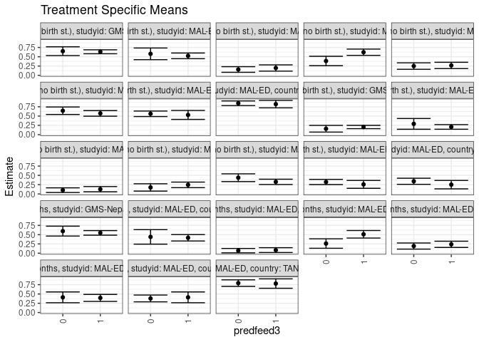

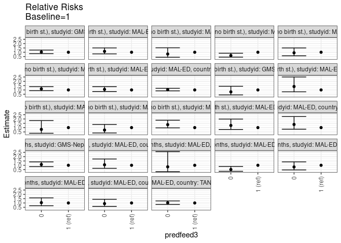

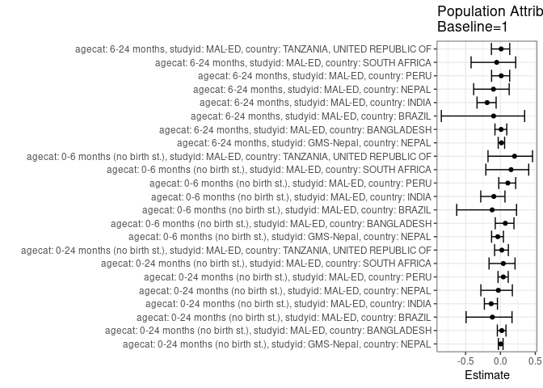

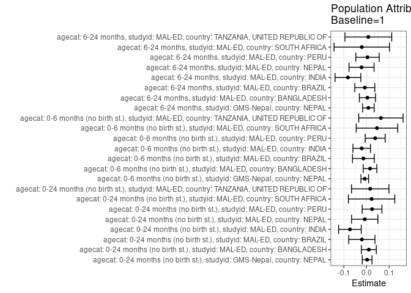

## Results Table

### Parameter: TSM

| agecat | studyid | country | intervention_level | baseline_level | estimate | ci_lower | ci_upper |
| --- | --- | --- | --- | --- | --- | --- | --- |
| 0-24 months (no birth st.) | GMS-Nepal | NEPAL | 1 | NA | 0.6340694 | 0.5809738 | 0.6871650 |
| 0-24 months (no birth st.) | GMS-Nepal | NEPAL | 0 | NA | 0.6507937 | 0.5329211 | 0.7686662 |
| 0-24 months (no birth st.) | MAL-ED | BANGLADESH | 1 | NA | 0.5243902 | 0.4477677 | 0.6010128 |
| 0-24 months (no birth st.) | MAL-ED | BANGLADESH | 0 | NA | 0.5789474 | 0.4215775 | 0.7363173 |
| 0-24 months (no birth st.) | MAL-ED | BRAZIL | 1 | NA | 0.1976744 | 0.1132644 | 0.2820844 |
| 0-24 months (no birth st.) | MAL-ED | BRAZIL | 0 | NA | 0.1573034 | 0.0814452 | 0.2331615 |
| 0-24 months (no birth st.) | MAL-ED | INDIA | 1 | NA | 0.6220472 | 0.5374882 | 0.7066063 |
| 0-24 months (no birth st.) | MAL-ED | INDIA | 0 | NA | 0.3859649 | 0.2592393 | 0.5126906 |
| 0-24 months (no birth st.) | MAL-ED | NEPAL | 1 | NA | 0.2666667 | 0.1818714 | 0.3514619 |
| 0-24 months (no birth st.) | MAL-ED | NEPAL | 0 | NA | 0.2500000 | 0.1631647 | 0.3368353 |
| 0-24 months (no birth st.) | MAL-ED | PERU | 1 | NA | 0.5722892 | 0.4968778 | 0.6477005 |
| 0-24 months (no birth st.) | MAL-ED | PERU | 0 | NA | 0.6436782 | 0.5428448 | 0.7445115 |
| 0-24 months (no birth st.) | MAL-ED | SOUTH AFRICA | 1 | NA | 0.5303030 | 0.4096425 | 0.6509636 |
| 0-24 months (no birth st.) | MAL-ED | SOUTH AFRICA | 0 | NA | 0.5614035 | 0.4868723 | 0.6359347 |
| 0-24 months (no birth st.) | MAL-ED | TANZANIA, UNITED REPUBLIC OF | 1 | NA | 0.8214286 | 0.7208462 | 0.9220110 |
| 0-24 months (no birth st.) | MAL-ED | TANZANIA, UNITED REPUBLIC OF | 0 | NA | 0.8449612 | 0.7823332 | 0.9075893 |
| 0-6 months (no birth st.) | GMS-Nepal | NEPAL | 1 | NA | 0.2050473 | 0.1605444 | 0.2495502 |
| 0-6 months (no birth st.) | GMS-Nepal | NEPAL | 0 | NA | 0.1587302 | 0.0683762 | 0.2490842 |
| 0-6 months (no birth st.) | MAL-ED | BANGLADESH | 1 | NA | 0.2073171 | 0.1451198 | 0.2695143 |
| 0-6 months (no birth st.) | MAL-ED | BANGLADESH | 0 | NA | 0.2894737 | 0.1449202 | 0.4340272 |
| 0-6 months (no birth st.) | MAL-ED | BRAZIL | 1 | NA | 0.1279070 | 0.0571170 | 0.1986970 |
| 0-6 months (no birth st.) | MAL-ED | BRAZIL | 0 | NA | 0.1011236 | 0.0383071 | 0.1639401 |
| 0-6 months (no birth st.) | MAL-ED | INDIA | 1 | NA | 0.2440945 | 0.1691840 | 0.3190049 |
| 0-6 months (no birth st.) | MAL-ED | INDIA | 0 | NA | 0.1754386 | 0.0764311 | 0.2744461 |
| 0-6 months (no birth st.) | MAL-ED | PERU | 1 | NA | 0.3253012 | 0.2538924 | 0.3967100 |
| 0-6 months (no birth st.) | MAL-ED | PERU | 0 | NA | 0.4367816 | 0.3323531 | 0.5412101 |
| 0-6 months (no birth st.) | MAL-ED | SOUTH AFRICA | 1 | NA | 0.2575758 | 0.1518519 | 0.3632996 |
| 0-6 months (no birth st.) | MAL-ED | SOUTH AFRICA | 0 | NA | 0.3216374 | 0.2514786 | 0.3917963 |
| 0-6 months (no birth st.) | MAL-ED | TANZANIA, UNITED REPUBLIC OF | 1 | NA | 0.2500000 | 0.1362814 | 0.3637186 |
| 0-6 months (no birth st.) | MAL-ED | TANZANIA, UNITED REPUBLIC OF | 0 | NA | 0.3410853 | 0.2590546 | 0.4231159 |
| 6-24 months | GMS-Nepal | NEPAL | 1 | NA | 0.5483871 | 0.4863468 | 0.6104274 |
| 6-24 months | GMS-Nepal | NEPAL | 0 | NA | 0.5961538 | 0.4625686 | 0.7297391 |
| 6-24 months | MAL-ED | BANGLADESH | 1 | NA | 0.4160000 | 0.3293041 | 0.5026959 |
| 6-24 months | MAL-ED | BANGLADESH | 0 | NA | 0.4400000 | 0.2447680 | 0.6352320 |
| 6-24 months | MAL-ED | BRAZIL | 1 | NA | 0.0845070 | 0.0195813 | 0.1494328 |
| 6-24 months | MAL-ED | BRAZIL | 0 | NA | 0.0694444 | 0.0105200 | 0.1283689 |
| 6-24 months | MAL-ED | INDIA | 1 | NA | 0.5106383 | 0.4092209 | 0.6120557 |
| 6-24 months | MAL-ED | INDIA | 0 | NA | 0.2608696 | 0.1335198 | 0.3882193 |
| 6-24 months | MAL-ED | NEPAL | 1 | NA | 0.2400000 | 0.1560697 | 0.3239303 |
| 6-24 months | MAL-ED | NEPAL | 0 | NA | 0.1931818 | 0.1104760 | 0.2758876 |
| 6-24 months | MAL-ED | PERU | 1 | NA | 0.3942308 | 0.2999914 | 0.4884702 |
| 6-24 months | MAL-ED | PERU | 0 | NA | 0.4090909 | 0.2633222 | 0.5548596 |
| 6-24 months | MAL-ED | SOUTH AFRICA | 1 | NA | 0.4090909 | 0.2633353 | 0.5548465 |
| 6-24 months | MAL-ED | SOUTH AFRICA | 0 | NA | 0.3796296 | 0.2878016 | 0.4714576 |
| 6-24 months | MAL-ED | TANZANIA, UNITED REPUBLIC OF | 1 | NA | 0.7804878 | 0.6532720 | 0.9077036 |
| 6-24 months | MAL-ED | TANZANIA, UNITED REPUBLIC OF | 0 | NA | 0.7926829 | 0.7045819 | 0.8807840 |

### Parameter: E(Y)

| agecat | studyid | country | intervention_level | baseline_level | estimate | ci_lower | ci_upper |
| --- | --- | --- | --- | --- | --- | --- | --- |
| 0-24 months (no birth st.) | GMS-Nepal | NEPAL | NA | NA | 0.6368421 | 0.5884257 | 0.6852585 |
| 0-24 months (no birth st.) | MAL-ED | BANGLADESH | NA | NA | 0.5346535 | 0.4656971 | 0.6036099 |
| 0-24 months (no birth st.) | MAL-ED | BRAZIL | NA | NA | 0.1771429 | 0.1204149 | 0.2338709 |
| 0-24 months (no birth st.) | MAL-ED | INDIA | NA | NA | 0.5489130 | 0.4768182 | 0.6210079 |
| 0-24 months (no birth st.) | MAL-ED | NEPAL | NA | NA | 0.2587065 | 0.1980144 | 0.3193985 |
| 0-24 months (no birth st.) | MAL-ED | PERU | NA | NA | 0.5968379 | 0.5362738 | 0.6574021 |
| 0-24 months (no birth st.) | MAL-ED | SOUTH AFRICA | NA | NA | 0.5527426 | 0.4893071 | 0.6161781 |
| 0-24 months (no birth st.) | MAL-ED | TANZANIA, UNITED REPUBLIC OF | NA | NA | 0.8378378 | 0.7845787 | 0.8910970 |
| 0-6 months (no birth st.) | GMS-Nepal | NEPAL | NA | NA | 0.1973684 | 0.1572979 | 0.2374390 |
| 0-6 months (no birth st.) | MAL-ED | BANGLADESH | NA | NA | 0.2227723 | 0.1652475 | 0.2802970 |
| 0-6 months (no birth st.) | MAL-ED | BRAZIL | NA | NA | 0.1142857 | 0.0670124 | 0.1615591 |
| 0-6 months (no birth st.) | MAL-ED | INDIA | NA | NA | 0.2228261 | 0.1625334 | 0.2831188 |
| 0-6 months (no birth st.) | MAL-ED | PERU | NA | NA | 0.3636364 | 0.3042435 | 0.4230292 |
| 0-6 months (no birth st.) | MAL-ED | SOUTH AFRICA | NA | NA | 0.3037975 | 0.2451226 | 0.3624723 |
| 0-6 months (no birth st.) | MAL-ED | TANZANIA, UNITED REPUBLIC OF | NA | NA | 0.3135135 | 0.2464813 | 0.3805457 |
| 6-24 months | GMS-Nepal | NEPAL | NA | NA | 0.5566667 | 0.5003580 | 0.6129753 |
| 6-24 months | MAL-ED | BANGLADESH | NA | NA | 0.4200000 | 0.3407510 | 0.4992490 |
| 6-24 months | MAL-ED | BRAZIL | NA | NA | 0.0769231 | 0.0330951 | 0.1207510 |
| 6-24 months | MAL-ED | INDIA | NA | NA | 0.4285714 | 0.3463030 | 0.5108399 |
| 6-24 months | MAL-ED | NEPAL | NA | NA | 0.2180851 | 0.1588990 | 0.2772712 |
| 6-24 months | MAL-ED | PERU | NA | NA | 0.3986486 | 0.3194990 | 0.4777982 |
| 6-24 months | MAL-ED | SOUTH AFRICA | NA | NA | 0.3881579 | 0.3104288 | 0.4658870 |
| 6-24 months | MAL-ED | TANZANIA, UNITED REPUBLIC OF | NA | NA | 0.7886179 | 0.7161684 | 0.8610674 |

### Parameter: RR

| agecat | studyid | country | intervention_level | baseline_level | estimate | ci_lower | ci_upper |
| --- | --- | --- | --- | --- | --- | --- | --- |
| 0-24 months (no birth st.) | GMS-Nepal | NEPAL | 1 | 1 | 1.0000000 | 1.0000000 | 1.0000000 |
| 0-24 months (no birth st.) | GMS-Nepal | NEPAL | 0 | 1 | 1.0263761 | 0.8407108 | 1.2530443 |
| 0-24 months (no birth st.) | MAL-ED | BANGLADESH | 1 | 1 | 1.0000000 | 1.0000000 | 1.0000000 |
| 0-24 months (no birth st.) | MAL-ED | BANGLADESH | 0 | 1 | 1.1040392 | 0.8108849 | 1.5031758 |
| 0-24 months (no birth st.) | MAL-ED | BRAZIL | 1 | 1 | 1.0000000 | 1.0000000 | 1.0000000 |
| 0-24 months (no birth st.) | MAL-ED | BRAZIL | 0 | 1 | 0.7957700 | 0.4178758 | 1.5154023 |
| 0-24 months (no birth st.) | MAL-ED | INDIA | 1 | 1 | 1.0000000 | 1.0000000 | 1.0000000 |
| 0-24 months (no birth st.) | MAL-ED | INDIA | 0 | 1 | 0.6204752 | 0.4349031 | 0.8852305 |
| 0-24 months (no birth st.) | MAL-ED | NEPAL | 1 | 1 | 1.0000000 | 1.0000000 | 1.0000000 |
| 0-24 months (no birth st.) | MAL-ED | NEPAL | 0 | 1 | 0.9375000 | 0.5854053 | 1.5013638 |
| 0-24 months (no birth st.) | MAL-ED | PERU | 1 | 1 | 1.0000000 | 1.0000000 | 1.0000000 |
| 0-24 months (no birth st.) | MAL-ED | PERU | 0 | 1 | 1.1247429 | 0.9165406 | 1.3802407 |
| 0-24 months (no birth st.) | MAL-ED | SOUTH AFRICA | 1 | 1 | 1.0000000 | 1.0000000 | 1.0000000 |
| 0-24 months (no birth st.) | MAL-ED | SOUTH AFRICA | 0 | 1 | 1.0586466 | 0.8134761 | 1.3777081 |
| 0-24 months (no birth st.) | MAL-ED | TANZANIA, UNITED REPUBLIC OF | 1 | 1 | 1.0000000 | 1.0000000 | 1.0000000 |
| 0-24 months (no birth st.) | MAL-ED | TANZANIA, UNITED REPUBLIC OF | 0 | 1 | 1.0286485 | 0.8914661 | 1.1869410 |
| 0-6 months (no birth st.) | GMS-Nepal | NEPAL | 1 | 1 | 1.0000000 | 1.0000000 | 1.0000000 |
| 0-6 months (no birth st.) | GMS-Nepal | NEPAL | 0 | 1 | 0.7741148 | 0.4209513 | 1.4235700 |
| 0-6 months (no birth st.) | MAL-ED | BANGLADESH | 1 | 1 | 1.0000000 | 1.0000000 | 1.0000000 |
| 0-6 months (no birth st.) | MAL-ED | BANGLADESH | 0 | 1 | 1.3962848 | 0.7797808 | 2.5002042 |
| 0-6 months (no birth st.) | MAL-ED | BRAZIL | 1 | 1 | 1.0000000 | 1.0000000 | 1.0000000 |
| 0-6 months (no birth st.) | MAL-ED | BRAZIL | 0 | 1 | 0.7906027 | 0.3440626 | 1.8166824 |
| 0-6 months (no birth st.) | MAL-ED | INDIA | 1 | 1 | 1.0000000 | 1.0000000 | 1.0000000 |
| 0-6 months (no birth st.) | MAL-ED | INDIA | 0 | 1 | 0.7187323 | 0.3780774 | 1.3663237 |
| 0-6 months (no birth st.) | MAL-ED | PERU | 1 | 1 | 1.0000000 | 1.0000000 | 1.0000000 |
| 0-6 months (no birth st.) | MAL-ED | PERU | 0 | 1 | 1.3426990 | 0.9705483 | 1.8575487 |
| 0-6 months (no birth st.) | MAL-ED | SOUTH AFRICA | 1 | 1 | 1.0000000 | 1.0000000 | 1.0000000 |
| 0-6 months (no birth st.) | MAL-ED | SOUTH AFRICA | 0 | 1 | 1.2487100 | 0.7845012 | 1.9876026 |
| 0-6 months (no birth st.) | MAL-ED | TANZANIA, UNITED REPUBLIC OF | 1 | 1 | 1.0000000 | 1.0000000 | 1.0000000 |
| 0-6 months (no birth st.) | MAL-ED | TANZANIA, UNITED REPUBLIC OF | 0 | 1 | 1.3643411 | 0.8155703 | 2.2823620 |
| 6-24 months | GMS-Nepal | NEPAL | 1 | 1 | 1.0000000 | 1.0000000 | 1.0000000 |
| 6-24 months | GMS-Nepal | NEPAL | 0 | 1 | 1.0871041 | 0.8457759 | 1.3972912 |
| 6-24 months | MAL-ED | BANGLADESH | 1 | 1 | 1.0000000 | 1.0000000 | 1.0000000 |
| 6-24 months | MAL-ED | BANGLADESH | 0 | 1 | 1.0576923 | 0.6478316 | 1.7268578 |
| 6-24 months | MAL-ED | BRAZIL | 1 | 1 | 1.0000000 | 1.0000000 | 1.0000000 |
| 6-24 months | MAL-ED | BRAZIL | 0 | 1 | 0.8217593 | 0.2615933 | 2.5814437 |
| 6-24 months | MAL-ED | INDIA | 1 | 1 | 1.0000000 | 1.0000000 | 1.0000000 |
| 6-24 months | MAL-ED | INDIA | 0 | 1 | 0.5108696 | 0.3015951 | 0.8653579 |
| 6-24 months | MAL-ED | NEPAL | 1 | 1 | 1.0000000 | 1.0000000 | 1.0000000 |
| 6-24 months | MAL-ED | NEPAL | 0 | 1 | 0.8049242 | 0.4631028 | 1.3990480 |
| 6-24 months | MAL-ED | PERU | 1 | 1 | 1.0000000 | 1.0000000 | 1.0000000 |
| 6-24 months | MAL-ED | PERU | 0 | 1 | 1.0376940 | 0.6756508 | 1.5937357 |
| 6-24 months | MAL-ED | SOUTH AFRICA | 1 | 1 | 1.0000000 | 1.0000000 | 1.0000000 |
| 6-24 months | MAL-ED | SOUTH AFRICA | 0 | 1 | 0.9279835 | 0.6032735 | 1.4274677 |
| 6-24 months | MAL-ED | TANZANIA, UNITED REPUBLIC OF | 1 | 1 | 1.0000000 | 1.0000000 | 1.0000000 |
| 6-24 months | MAL-ED | TANZANIA, UNITED REPUBLIC OF | 0 | 1 | 1.0156250 | 0.8337865 | 1.2371202 |

### Parameter: PAR

| agecat | studyid | country | intervention_level | baseline_level | estimate | ci_lower | ci_upper |
| --- | --- | --- | --- | --- | --- | --- | --- |
| 0-24 months (no birth st.) | GMS-Nepal | NEPAL | 1 | NA | 0.0027727 | -0.0186696 | 0.0242150 |
| 0-24 months (no birth st.) | MAL-ED | BANGLADESH | 1 | NA | 0.0102632 | -0.0227953 | 0.0433218 |
| 0-24 months (no birth st.) | MAL-ED | BRAZIL | 1 | NA | -0.0205316 | -0.0783261 | 0.0372630 |
| 0-24 months (no birth st.) | MAL-ED | INDIA | 1 | NA | -0.0731342 | -0.1229084 | -0.0233600 |
| 0-24 months (no birth st.) | MAL-ED | NEPAL | 1 | NA | -0.0079602 | -0.0659393 | 0.0500189 |
| 0-24 months (no birth st.) | MAL-ED | PERU | 1 | NA | 0.0245488 | -0.0189515 | 0.0680491 |
| 0-24 months (no birth st.) | MAL-ED | SOUTH AFRICA | 1 | NA | 0.0224396 | -0.0799041 | 0.1247833 |
| 0-24 months (no birth st.) | MAL-ED | TANZANIA, UNITED REPUBLIC OF | 1 | NA | 0.0164093 | -0.0662259 | 0.0990445 |
| 0-6 months (no birth st.) | GMS-Nepal | NEPAL | 1 | NA | -0.0076789 | -0.0244669 | 0.0091091 |
| 0-6 months (no birth st.) | MAL-ED | BANGLADESH | 1 | NA | 0.0154552 | -0.0144793 | 0.0453897 |
| 0-6 months (no birth st.) | MAL-ED | BRAZIL | 1 | NA | -0.0136213 | -0.0617946 | 0.0345521 |
| 0-6 months (no birth st.) | MAL-ED | INDIA | 1 | NA | -0.0212684 | -0.0600030 | 0.0174662 |
| 0-6 months (no birth st.) | MAL-ED | PERU | 1 | NA | 0.0383352 | -0.0056565 | 0.0823268 |
| 0-6 months (no birth st.) | MAL-ED | SOUTH AFRICA | 1 | NA | 0.0462217 | -0.0454015 | 0.1378449 |
| 0-6 months (no birth st.) | MAL-ED | TANZANIA, UNITED REPUBLIC OF | 1 | NA | 0.0635135 | -0.0344466 | 0.1614736 |
| 6-24 months | GMS-Nepal | NEPAL | 1 | NA | 0.0082796 | -0.0173326 | 0.0338918 |
| 6-24 months | MAL-ED | BANGLADESH | 1 | NA | 0.0040000 | -0.0316316 | 0.0396316 |
| 6-24 months | MAL-ED | BRAZIL | 1 | NA | -0.0075840 | -0.0517469 | 0.0365790 |
| 6-24 months | MAL-ED | INDIA | 1 | NA | -0.0820669 | -0.1390023 | -0.0251314 |
| 6-24 months | MAL-ED | NEPAL | 1 | NA | -0.0219149 | -0.0771721 | 0.0333424 |
| 6-24 months | MAL-ED | PERU | 1 | NA | 0.0044179 | -0.0471983 | 0.0560340 |
| 6-24 months | MAL-ED | SOUTH AFRICA | 1 | NA | -0.0209330 | -0.1433542 | 0.1014882 |
| 6-24 months | MAL-ED | TANZANIA, UNITED REPUBLIC OF | 1 | NA | 0.0081301 | -0.0950375 | 0.1112977 |

### Parameter: PAF

| agecat | studyid | country | intervention_level | baseline_level | estimate | ci_lower | ci_upper |
| --- | --- | --- | --- | --- | --- | --- | --- |
| 0-24 months (no birth st.) | GMS-Nepal | NEPAL | 1 | NA | 0.0043538 | -0.0298958 | 0.0374645 |
| 0-24 months (no birth st.) | MAL-ED | BANGLADESH | 1 | NA | 0.0191960 | -0.0446924 | 0.0791774 |
| 0-24 months (no birth st.) | MAL-ED | BRAZIL | 1 | NA | -0.1159040 | -0.4933958 | 0.1661677 |
| 0-24 months (no birth st.) | MAL-ED | INDIA | 1 | NA | -0.1332346 | -0.2308078 | -0.0433965 |
| 0-24 months (no birth st.) | MAL-ED | NEPAL | 1 | NA | -0.0307692 | -0.2810695 | 0.1706264 |
| 0-24 months (no birth st.) | MAL-ED | PERU | 1 | NA | 0.0411314 | -0.0348316 | 0.1115182 |
| 0-24 months (no birth st.) | MAL-ED | SOUTH AFRICA | 1 | NA | 0.0405968 | -0.1637306 | 0.2090485 |
| 0-24 months (no birth st.) | MAL-ED | TANZANIA, UNITED REPUBLIC OF | 1 | NA | 0.0195853 | -0.0842548 | 0.1134804 |
| 0-6 months (no birth st.) | GMS-Nepal | NEPAL | 1 | NA | -0.0389064 | -0.1273497 | 0.0425983 |
| 0-6 months (no birth st.) | MAL-ED | BANGLADESH | 1 | NA | 0.0693767 | -0.0745365 | 0.1940155 |
| 0-6 months (no birth st.) | MAL-ED | BRAZIL | 1 | NA | -0.1191860 | -0.6280671 | 0.2306353 |
| 0-6 months (no birth st.) | MAL-ED | INDIA | 1 | NA | -0.0954484 | -0.2829963 | 0.0646838 |
| 0-6 months (no birth st.) | MAL-ED | PERU | 1 | NA | 0.1054217 | -0.0241483 | 0.2185992 |
| 0-6 months (no birth st.) | MAL-ED | SOUTH AFRICA | 1 | NA | 0.1521465 | -0.2095239 | 0.4056706 |
| 0-6 months (no birth st.) | MAL-ED | TANZANIA, UNITED REPUBLIC OF | 1 | NA | 0.2025862 | -0.1787267 | 0.4605460 |
| 6-24 months | GMS-Nepal | NEPAL | 1 | NA | 0.0148735 | -0.0322658 | 0.0598601 |
| 6-24 months | MAL-ED | BANGLADESH | 1 | NA | 0.0095238 | -0.0790616 | 0.0908368 |
| 6-24 months | MAL-ED | BRAZIL | 1 | NA | -0.0985915 | -0.8488735 | 0.3472223 |
| 6-24 months | MAL-ED | INDIA | 1 | NA | -0.1914894 | -0.3364455 | -0.0622558 |
| 6-24 months | MAL-ED | NEPAL | 1 | NA | -0.1004878 | -0.3846904 | 0.1253832 |
| 6-24 months | MAL-ED | PERU | 1 | NA | 0.0110821 | -0.1272609 | 0.1324470 |
| 6-24 months | MAL-ED | SOUTH AFRICA | 1 | NA | -0.0539291 | -0.4216756 | 0.2186919 |
| 6-24 months | MAL-ED | TANZANIA, UNITED REPUBLIC OF | 1 | NA | 0.0103093 | -0.1295766 | 0.1328718 |